# Data Vis Beastiary

ANLY 580

May 10, 2016

## Objectives

This assigment will help you familiarize yourself with the process of writing reproducible code and with sharing that code through a social portal such as GitHub.

Your code is (theoretically) because the assignment was due last week. Since then you were asked to setup a GitHub account. Now you will use that account to add your code to this repo.

Your tasks are: - Fork the repo to your local machine - Add your code below your name - Add some description of the vis and the data set above your graphic - Test your code on your local machine to verify execution - Create a pull request to submit your code to the master branch

No doubt this will require some reading and thoughtful research on your part. A great source of information can be found at http://kbroman.org/github_tutorial/

## Kevin Purcell (Instructor)

A *treemap* is a visual representation of a hierarchical (tree-like) dataset. In which each branch of hierarchy is represented by rectangle. The appearence of the treemap (size & color of rectangles) is scaled in relation to one or multiple varibles in the dataset.

```r
library(treemap)   # Loading the treemap library
```

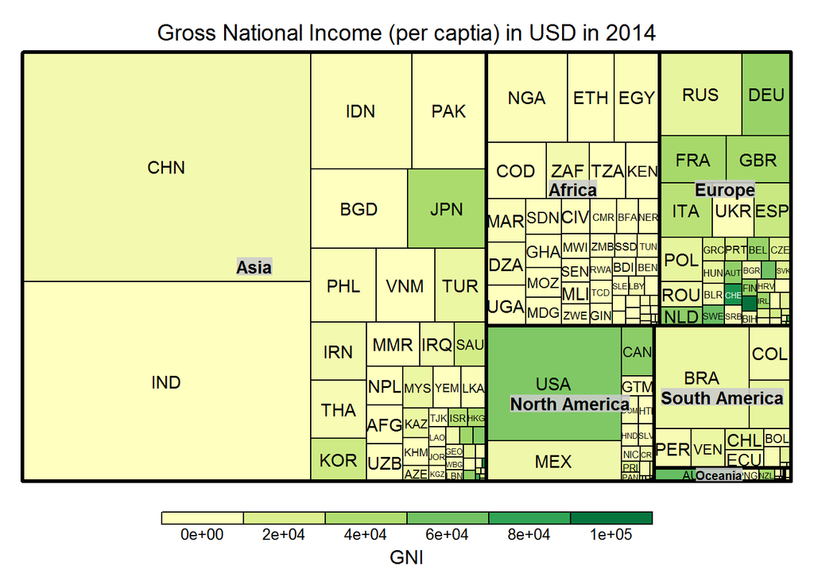

```r
data(GNI2014)      # Included dataset on Gross National Income levels
treemap(GNI2014,                     # data frme
       index=c("continent", "iso3"), # a vector of aggregation indices from df
       vSize="population",           # identify the column that defines size
       vColor="GNI",                 # second vector to map to color
       type="value",                 # a type (7 choices)
       title="Gross National Income (per captia) in USD in 2014")
```

## Olayemi Adejumo

## Isaac Cyril

Below is my example with four box plots using the `iris` dataset, which gives the measurements in centimeters of the variables sepal length and width and petal length and width, respectively, for 50 flowers from each of 3 species of iris. The species are Iris setosa, versicolor, and virginica.

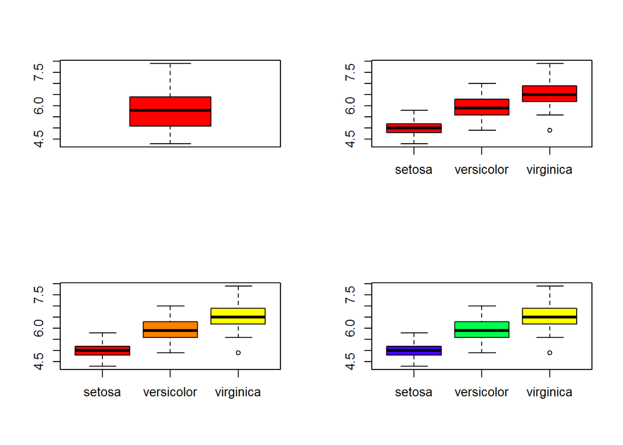

```r
data("iris") #loading iris data
par(mfrow=c(2,2)) #Creating a matrix 2 rows and 2 columns
boxplot(iris$Sepal.Length,col="red") #Box plot of the sepal length in red
boxplot(iris$Sepal.Length~iris$Species,col="red") #Box plot of sepal length and species in red
boxplot(iris$Sepal.Length~iris$Species,col=heat.colors(3)) #Box plots with three heat colors
boxplot(iris$Sepal.Length~iris$Species,col=topo.colors(3)) #Box plots with three topo colors
```

## Ying Dong

## Rui Fan

## Sukanyaraj Govindaraaj

The “Plotly” package is used to translate ggplot2 graphs to an interactive web-based version and/or create custom web-based visualizations directly from R. The “Diamonds” dataset contains the prices and other attributes such as carat, quality, color, clariyt etc. of almost 54,000 diamonds.The blow chart is an interactive R plot the shows the variation in diamond price and carat, weight of diamond.

```r
library(plotly)
data(diamonds)
set.seed(100)
d <- diamonds[sample(nrow(diamonds), 1000), ]
plot_ly(d, x = carat, y = price, text = paste("Clarity: ", clarity),
        mode = "markers", color = carat, size = carat)
```

[interactive chart not shown]

## Kan Hui

A *rUnemploymentData* contains data and visualization functions for USA unemployment data from 2000 to 2013. Data comes from the US Bureau of Labor Statistics.

Below is my example of a vis created with the `rUnemploymentData` package using the `df_state_unemployment` dataset, which is a distribution of unemployment rate in 10 States of the U.S.

```r
library(rUnemploymentData)   #load rUnemploymentData library
library(reshape)             #load reshape library
```

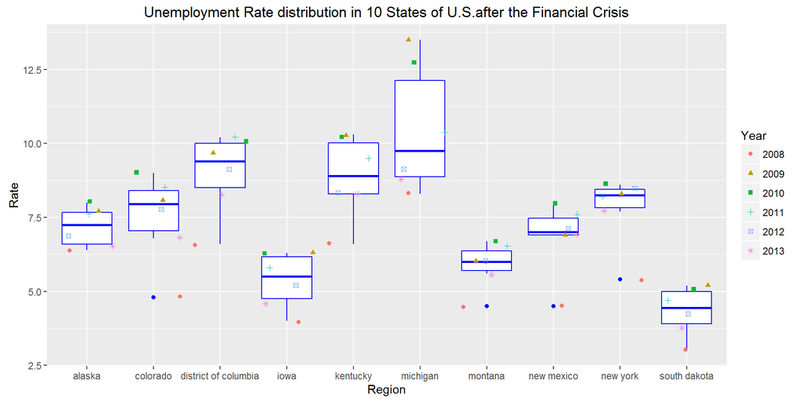

```r
library(ggplot2)            #load ggplot2 library

data(df_state_unemployment)

pick<-sort(sample(51,10))
db3<-melt(df_state_unemployment[pick,c(1,10:15)],
          id="region")                       #manipulate data and pick 10 states out of 51 states
colnames(db3)<-c("Region","Year","Rate")     #rename the column names

ggplot(data = db3, aes(Region,Rate))+
  geom_boxplot(colour="blue")+               #apply ggplot function with box plot
  geom_jitter(aes(colour=Year,shape=Year))+  #add jitter
  ggtitle("Unemployment Rate distribution in 10 States of U.S.after the Financial Crisis")   #add title
```

## Muhammad Huzaifa

## Xinyi Li

This package offers an alternative. The data.tree package lets you create hierarchies, called data.tree structures. The building block of theses structures are Node objects. The package provides basic traversal, search, and sort operations, and an infrastructure for recursive tree programming. You can decorate Nodes with your own fields and methods, so as to extend the package to your needs.

The package also provides convenience methods for neatly printing and plotting trees. It supports conversion from and to data.frames, lists, and other tree structures such as dendrogram, phylo objects from the ape package, igraph, and other packages.

Technically, data.tree structures are bi-directional, ordered trees. Bi-directional means that you can navigate from parent to chidren and vice versa. Ordered means that the sort order of the children of a parent node is well-defined.

```r
library(data.tree) # Loading the data.tree library
library(networkD3) # Loading the networkD3 library
```

```r
data(acme) # Included dataset of Sample Data: A Simple Company with Departments
acmeNetwork <- ToDataFrameNetwork(acme, "name") #Transform into frame network
simpleNetwork(acmeNetwork[-3], fontSize = 12) #Plot and settings
```

[interactive chart not shown]

## Shen Liu This is the example to use ggplot2, which is one decent tool in R to visualize the dataset. In following example, we use dataset airquality to explore the relationship between ozone content and temperature.

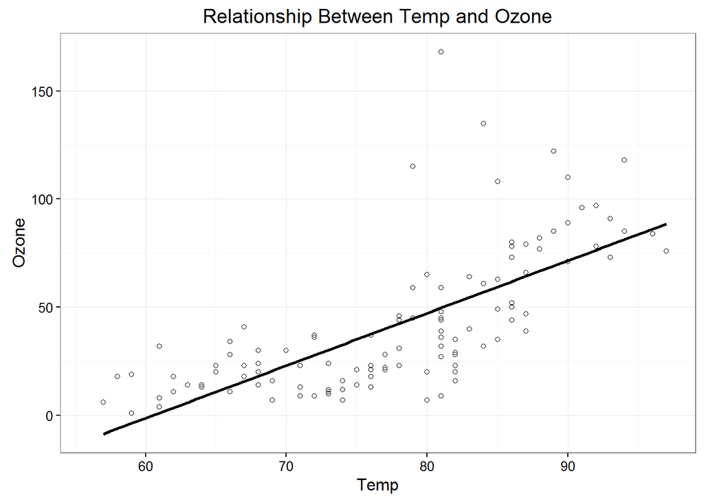

```r
   data11 <- data.frame(airquality) #get data
   ggplot(data11, aes(x = Temp, y = Ozone)) + #draw plot as Temp for independent variable and Ozone for dependent Var.
   geom_point(shape = 1) + #point shape
   geom_smooth(method = "lm", formula = y~x, se = FALSE, colour = "black") +   #linear regression
   labs(x = "Temp", y = "Ozone") + #axis title
   ggtitle("Relationship Between Temp and Ozone") + #graph title
   theme_bw()
```

## Vishwanath Kuma Maharajapuram Ramachandran ## Jai Rajora ## Yuanhui Sui ## Shanfeng Tang ## Russell Taylor ## Gokul Krishna Turaga ## Bongyong Uh ## Xinting Zhang ## Sicong Zheng